# "Анализ убытков мобильного приложения Procrastinate Pro+"

## Описание проекта.

Несколько месяцев развлекательное мобильное приложение "Procrastinate Pro+" терпит убытки. В привлечение пользователей вкладываются большие средства, но это не приносит результатов.

Нужно разобраться в причинах этой ситуации.

Для анализа предоставлены лог сервера с данными о посещениях приложения новыми пользователями, зарегистрировавшимися в период с 2019-05-01 по 2019-10-27, выгрузка их покупок за этот период, а также статистика рекламных расходов.

Необходимо изучить, как люди пользуются продуктом, когда они начинают покупать, сколько денег приносит каждый клиент, когда он окупается и какие факторы отричательно влияют на привлечение пользователей.

**Описание данных.**

Таблица visits_log_short (лог сервера с информацией о посещениях сайта):

```
User Id — уникальный идентификатор пользователя
Device — категория устройства пользователя
Session start — дата и время начала сессии
Session End — дата и время окончания сессии
Channel — идентификатор рекламного источника, из которого пришел пользователь
Region - страна пользователя
```

Таблица orders_log_short (информация о заказах):

```
User Id — уникальный id пользователя, который сделал заказ
Event Dt — дата и время покупки
Revenue — выручка
```

Таблица costs_short (информация о затратах на маркетинг):

```
Channel — идентификатор рекламного источника
Dt — дата
Costs — затраты на этот рекламный источник в этот день
```

```python
import pandas as pd
import numpy as np
import matplotlib.pyplot as plt
import warnings
from datetime import datetime, timedelta
```

## Подготовка данных к анализу

```python
visits, orders, costs = (
    pd.read_csv('visits_info_short.csv'),  # журнал сессий
    pd.read_csv('orders_info_short.csv'),  # покупки
    pd.read_csv('costs_info_short.csv'),  # траты на рекламу
)
```

```python
visits.info()
```

```
<class 'pandas.core.frame.DataFrame'>
RangeIndex: 309901 entries, 0 to 309900
Data columns (total 6 columns):
 #   Column         Non-Null Count   Dtype
---  ------         --------------   -----
 0   User Id        309901 non-null  int64
 1   Region         309901 non-null  object
 2   Device         309901 non-null  object
 3   Channel        309901 non-null  object
 4   Session Start  309901 non-null  object
 5   Session End    309901 non-null  object
dtypes: int64(1), object(5)
memory usage: 14.2+ MB
```

```python
orders.info()
```

```
<class 'pandas.core.frame.DataFrame'>
RangeIndex: 40212 entries, 0 to 40211
Data columns (total 3 columns):
 #   Column    Non-Null Count  Dtype
---  ------    --------------  -----
 0   User Id   40212 non-null  int64
 1   Event Dt  40212 non-null  object
 2   Revenue   40212 non-null  float64
dtypes: float64(1), int64(1), object(1)
memory usage: 942.6+ KB
```

```python
costs.info()
```

```
<class 'pandas.core.frame.DataFrame'>
RangeIndex: 1800 entries, 0 to 1799
Data columns (total 3 columns):
 #   Column   Non-Null Count  Dtype
---  ------   --------------  -----
 0   dt       1800 non-null   object
 1   Channel  1800 non-null   object
 2   costs    1800 non-null   float64
dtypes: float64(1), object(2)
memory usage: 42.3+ KB
```

Приведем названия столбцов нижнему регистру и уберем пробелы, записав названия столбцов в "змеином регистре"

```python
visits = visits.rename(columns={'User Id':'user_id', 'Session Start':'session_start', 'Session End':'session_end'})
orders = orders.rename(columns={'User Id':'user_id', 'Event Dt':'event_dt'})
```

```python
visits.columns = visits.columns.str.lower()
orders.columns = orders.columns.str.lower()
costs.columns = costs.columns.str.lower()
```

```python
visits.columns
```

```
Index(['user_id', 'region', 'device', 'channel', 'session_start',
       'session_end'],
      dtype='object')
```

```python
orders.columns
```

```
Index(['user_id', 'event_dt', 'revenue'], dtype='object')
```

```python
costs.columns
```

```
Index(['dt', 'channel', 'costs'], dtype='object')
```

Приведем данные, содержащие дату к формату `datetime`

```python
visits['session_start'] = pd.to_datetime(visits['session_start'])
visits['session_end'] = pd.to_datetime(visits['session_end'])
orders['event_dt'] = pd.to_datetime(orders['event_dt'])
costs['dt'] = pd.to_datetime(costs['dt']).dt.date
```

Запросим вновь информацию о таблицах, проверим результат

```python
visits.info()
```

```
<class 'pandas.core.frame.DataFrame'>
RangeIndex: 309901 entries, 0 to 309900
Data columns (total 6 columns):
 #   Column         Non-Null Count   Dtype
---  ------         --------------   -----
 0   user_id        309901 non-null  int64
 1   region         309901 non-null  object
 2   device         309901 non-null  object
 3   channel        309901 non-null  object
 4   session_start  309901 non-null  datetime64[ns]
 5   session_end    309901 non-null  datetime64[ns]
dtypes: datetime64[ns](2), int64(1), object(3)
memory usage: 14.2+ MB
```

```python
orders.info()
```

```
<class 'pandas.core.frame.DataFrame'>
RangeIndex: 40212 entries, 0 to 40211
Data columns (total 3 columns):
 #   Column    Non-Null Count  Dtype
---  ------    --------------  -----
 0   user_id   40212 non-null  int64
 1   event_dt  40212 non-null  datetime64[ns]
 2   revenue   40212 non-null  float64
dtypes: datetime64[ns](1), float64(1), int64(1)
memory usage: 942.6 KB
```

```python
costs.info()
```

```
<class 'pandas.core.frame.DataFrame'>
RangeIndex: 1800 entries, 0 to 1799
Data columns (total 3 columns):
 #   Column   Non-Null Count  Dtype
---  ------   --------------  -----
 0   dt       1800 non-null   object
 1   channel  1800 non-null   object
 2   costs    1800 non-null   float64
dtypes: float64(1), object(2)
memory usage: 42.3+ KB
```

Посмотрим на данные в таблицах, проверим на дубликаты

```python
visits.head(5)
```

|  | user_id | region | device | channel | session_start | session_end |
| --- | --- | --- | --- | --- | --- | --- |
| 0 | 981449118918 | United States | iPhone | organic | 2019-05-01 02:36:01 | 2019-05-01 02:45:01 |
| 1 | 278965908054 | United States | iPhone | organic | 2019-05-01 04:46:31 | 2019-05-01 04:47:35 |
| 2 | 590706206550 | United States | Mac | organic | 2019-05-01 14:09:25 | 2019-05-01 15:32:08 |
| 3 | 326433527971 | United States | Android | TipTop | 2019-05-01 00:29:59 | 2019-05-01 00:54:25 |
| 4 | 349773784594 | United States | Mac | organic | 2019-05-01 03:33:35 | 2019-05-01 03:57:40 |

```python
display(visits['region'].unique())
display(visits['device'].unique())
visits['channel'].unique()
```

```
array(['United States', 'UK', 'France', 'Germany'], dtype=object)
```

```
array(['iPhone', 'Mac', 'Android', 'PC'], dtype=object)
```

```
array(['organic', 'TipTop', 'RocketSuperAds', 'YRabbit', 'FaceBoom',
       'MediaTornado', 'AdNonSense', 'LeapBob', 'WahooNetBanner',
       'OppleCreativeMedia', 'lambdaMediaAds'], dtype=object)
```

```python
visits.duplicated().sum()
```

```
0
```

Неявных и полных дубликатов в таблице `visits` нет

```python
orders.head(5)
```

|  | user_id | event_dt | revenue |
| --- | --- | --- | --- |
| 0 | 188246423999 | 2019-05-01 23:09:52 | 4.99 |
| 1 | 174361394180 | 2019-05-01 12:24:04 | 4.99 |
| 2 | 529610067795 | 2019-05-01 11:34:04 | 4.99 |
| 3 | 319939546352 | 2019-05-01 15:34:40 | 4.99 |
| 4 | 366000285810 | 2019-05-01 13:59:51 | 4.99 |

```python
orders.duplicated().sum()
```

```
0
```

Таблица `orders` также не содержет дубликатов.

```python
costs.head(5)
```

|  | dt | channel | costs |
| --- | --- | --- | --- |
| 0 | 2019-05-01 | FaceBoom | 113.3 |
| 1 | 2019-05-02 | FaceBoom | 78.1 |
| 2 | 2019-05-03 | FaceBoom | 85.8 |
| 3 | 2019-05-04 | FaceBoom | 136.4 |
| 4 | 2019-05-05 | FaceBoom | 122.1 |

```python
costs['channel'].sort_values().unique()
```

```
array(['AdNonSense', 'FaceBoom', 'LeapBob', 'MediaTornado',
       'OppleCreativeMedia', 'RocketSuperAds', 'TipTop', 'WahooNetBanner',
       'YRabbit', 'lambdaMediaAds'], dtype=object)
```

Сравним с каналами привлечения в таблице `visits`

```python
visits['channel'].sort_values().unique()
```

```
array(['AdNonSense', 'FaceBoom', 'LeapBob', 'MediaTornado',
       'OppleCreativeMedia', 'RocketSuperAds', 'TipTop', 'WahooNetBanner',
       'YRabbit', 'lambdaMediaAds', 'organic'], dtype=object)
```

Неявных дубликатов в названиях каналов привлечения пользователей нет. В таблицах `visits` и `costs`названия совпадают, в том числе и по регистрам.

```python
costs.duplicated().sum()
```

```
0
```

Полных дубликатов в таблице `costs` нет.

**Вывод**

Для исследования нам предоставлены таблицы с данными о визитах пользователей, заказах и тратах на рекламу. Данные выгружены в таблицы `visits`, `orders` и `costs` соответственно.

Объем данных в таблице `visits` - 14.2MB (содержит 6 столбцов, 309901 строку)

Объем данных в таблице `orders` - 942.6KB (содержит 3 столбца, 40212 строк)

Объем данных в таблице `costs` - 42.3KB (содержит 3 столбца, 1800 строк)

В ходе предобработки были обнаружены следующие проблемы с данными:

- нарушения в стиле заголовков (названия столбцов записаны с использованием двух регистров и содержали пробелы)
- несоответствие типов данных - данные содержащие дату, сохранены в формате `object`

Названия столбцов привели к нижнему регистру и записали в "змеином регистре". Столбцы, содержащие дату привели к формату `datetime`

Можно сказать, что таблицы содержат корректные данные и готовы к дальнейшему анализу.

## Функции для расчета и анализа LTV, ROI, удержания и конверсии

### Функция для создания пользовательских профилей

```python
def get_profiles(sessions, orders, ad_costs):

    # находим параметры первых посещений
    profiles = (
        sessions.sort_values(by=['user_id', 'session_start'])
        .groupby('user_id')
        .agg(
            {
                'session_start': 'first',
                'channel': 'first',
                'device': 'first',
                'region': 'first',
            }
        )
        .rename(columns={'session_start': 'first_ts'})
        .reset_index()
    )

    # для когортного анализа определяем дату первого посещения
    # и первый день месяца, в который это посещение произошло
    profiles['dt'] = profiles['first_ts'].dt.date
    profiles['month'] = profiles['first_ts'].astype('datetime64[M]')

    # добавляем признак платящих пользователей
    profiles['payer'] = profiles['user_id'].isin(orders['user_id'].unique())


    # считаем количество уникальных пользователей
    # с одинаковыми источником и датой привлечения
    new_users = (
        profiles.groupby(['dt', 'channel'])
        .agg({'user_id': 'nunique'})
        .rename(columns={'user_id': 'unique_users'})
        .reset_index()
    )

    # объединяем траты на рекламу и число привлечённых пользователей
    ad_costs = ad_costs.merge(new_users, on=['dt', 'channel'], how='left')

    # делим рекламные расходы на число привлечённых пользователей
    ad_costs['acquisition_cost'] = ad_costs['costs'] / ad_costs['unique_users']

    # добавляем стоимость привлечения в профили
    profiles = profiles.merge(
        ad_costs[['dt', 'channel', 'acquisition_cost']],
        on=['dt', 'channel'],
        how='left',
    )

    # стоимость привлечения органических пользователей равна нулю
    profiles['acquisition_cost'] = profiles['acquisition_cost'].fillna(0)

    return profiles
```

### Функции для расчетов

**Функция для расчета удержания**

```python
def get_retention(
    profiles,
    sessions,
    observation_date,
    horizon_days,
    dimensions=[],
    ignore_horizon=False,
):

    # добавляем столбец payer в передаваемый dimensions список
    dimensions = ['payer'] + dimensions

    # исключаем пользователей, не «доживших» до горизонта анализа
    last_suitable_acquisition_date = observation_date
    if not ignore_horizon:
        last_suitable_acquisition_date = observation_date - timedelta(
            days=horizon_days - 1
        )
    result_raw = profiles.query('dt <= @last_suitable_acquisition_date')

    # собираем «сырые» данные для расчёта удержания
    result_raw = result_raw.merge(
        sessions[['user_id', 'session_start']], on='user_id', how='left'
    )
    result_raw['lifetime'] = (
        result_raw['session_start'] - result_raw['first_ts']
    ).dt.days

    # функция для группировки таблицы по желаемым признакам
    def group_by_dimensions(df, dims, horizon_days):
        result = df.pivot_table(
            index=dims, columns='lifetime', values='user_id', aggfunc='nunique'
        )
        cohort_sizes = (
            df.groupby(dims)
            .agg({'user_id': 'nunique'})
            .rename(columns={'user_id': 'cohort_size'})
        )
        result = cohort_sizes.merge(result, on=dims, how='left').fillna(0)
        result = result.div(result['cohort_size'], axis=0)
        result = result[['cohort_size'] + list(range(horizon_days))]
        result['cohort_size'] = cohort_sizes
        return result

    # получаем таблицу удержания
    result_grouped = group_by_dimensions(result_raw, dimensions, horizon_days)

    # получаем таблицу динамики удержания
    result_in_time = group_by_dimensions(
        result_raw, dimensions + ['dt'], horizon_days
    )

    # возвращаем обе таблицы и сырые данные
    return result_raw, result_grouped, result_in_time
```

**Функция для расчета конверсии**

```python
# функция для расчёта конверсии

def get_conversion(
    profiles,
    purchases,
    observation_date,
    horizon_days,
    dimensions=[],
    ignore_horizon=False,
):

    # исключаем пользователей, не «доживших» до горизонта анализа
    last_suitable_acquisition_date = observation_date
    if not ignore_horizon:
        last_suitable_acquisition_date = observation_date - timedelta(
            days=horizon_days - 1
        )
    result_raw = profiles.query('dt <= @last_suitable_acquisition_date')

    # определяем дату и время первой покупки для каждого пользователя
    first_purchases = (
        purchases.sort_values(by=['user_id', 'event_dt'])
        .groupby('user_id')
        .agg({'event_dt': 'first'})
        .reset_index()
    )

    # добавляем данные о покупках в профили
    result_raw = result_raw.merge(
        first_purchases[['user_id', 'event_dt']], on='user_id', how='left'
    )

    # рассчитываем лайфтайм для каждой покупки
    result_raw['lifetime'] = (
        result_raw['event_dt'] - result_raw['first_ts']
    ).dt.days

    # группируем по cohort, если в dimensions ничего нет
    if len(dimensions) == 0:
        result_raw['cohort'] = 'All users'
        dimensions = dimensions + ['cohort']

    # функция для группировки таблицы по желаемым признакам
    def group_by_dimensions(df, dims, horizon_days):
        result = df.pivot_table(
            index=dims, columns='lifetime', values='user_id', aggfunc='nunique'
        )
        result = result.fillna(0).cumsum(axis = 1)
        cohort_sizes = (
            df.groupby(dims)
            .agg({'user_id': 'nunique'})
            .rename(columns={'user_id': 'cohort_size'})
        )
        result = cohort_sizes.merge(result, on=dims, how='left').fillna(0)
        # делим каждую «ячейку» в строке на размер когорты
        # и получаем conversion rate
        result = result.div(result['cohort_size'], axis=0)
        result = result[['cohort_size'] + list(range(horizon_days))]
        result['cohort_size'] = cohort_sizes
        return result

    # получаем таблицу конверсии
    result_grouped = group_by_dimensions(result_raw, dimensions, horizon_days)

    # для таблицы динамики конверсии убираем 'cohort' из dimensions
    if 'cohort' in dimensions:
        dimensions = []

    # получаем таблицу динамики конверсии
    result_in_time = group_by_dimensions(
        result_raw, dimensions + ['dt'], horizon_days
    )

    # возвращаем обе таблицы и сырые данные
    return result_raw, result_grouped, result_in_time
```

**Функция для расчета LTV и ROI**

```python
def get_ltv(
    profiles,
    purchases,
    observation_date,
    horizon_days,
    dimensions=[],
    ignore_horizon=False,
):

    # исключаем пользователей, не «доживших» до горизонта анализа
    last_suitable_acquisition_date = observation_date
    if not ignore_horizon:
        last_suitable_acquisition_date = observation_date - timedelta(
            days=horizon_days - 1
        )
    result_raw = profiles.query('dt <= @last_suitable_acquisition_date')
    # добавляем данные о покупках в профили
    result_raw = result_raw.merge(
        purchases[['user_id', 'event_dt', 'revenue']], on='user_id', how='left'
    )
    # рассчитываем лайфтайм пользователя для каждой покупки
    result_raw['lifetime'] = (
        result_raw['event_dt'] - result_raw['first_ts']
    ).dt.days
    # группируем по cohort, если в dimensions ничего нет
    if len(dimensions) == 0:
        result_raw['cohort'] = 'All users'
        dimensions = dimensions + ['cohort']

    # функция группировки по желаемым признакам
    def group_by_dimensions(df, dims, horizon_days):
        # строим «треугольную» таблицу выручки
        result = df.pivot_table(
            index=dims, columns='lifetime', values='revenue', aggfunc='sum'
        )
        # находим сумму выручки с накоплением
        result = result.fillna(0).cumsum(axis=1)
        # вычисляем размеры когорт
        cohort_sizes = (
            df.groupby(dims)
            .agg({'user_id': 'nunique'})
            .rename(columns={'user_id': 'cohort_size'})
        )
        # объединяем размеры когорт и таблицу выручки
        result = cohort_sizes.merge(result, on=dims, how='left').fillna(0)
        # считаем LTV: делим каждую «ячейку» в строке на размер когорты
        result = result.div(result['cohort_size'], axis=0)
        # исключаем все лайфтаймы, превышающие горизонт анализа
        result = result[['cohort_size'] + list(range(horizon_days))]
        # восстанавливаем размеры когорт
        result['cohort_size'] = cohort_sizes

        # собираем датафрейм с данными пользователей и значениями CAC,
        # добавляя параметры из dimensions
        cac = df[['user_id', 'acquisition_cost'] + dims].drop_duplicates()

        # считаем средний CAC по параметрам из dimensions
        cac = (
            cac.groupby(dims)
            .agg({'acquisition_cost': 'mean'})
            .rename(columns={'acquisition_cost': 'cac'})
        )

        # считаем ROI: делим LTV на CAC
        roi = result.div(cac['cac'], axis=0)

        # удаляем строки с бесконечным ROI
        roi = roi[~roi['cohort_size'].isin([np.inf])]

        # восстанавливаем размеры когорт в таблице ROI
        roi['cohort_size'] = cohort_sizes

        # добавляем CAC в таблицу ROI
        roi['cac'] = cac['cac']

        # в финальной таблице оставляем размеры когорт, CAC
        # и ROI в лайфтаймы, не превышающие горизонт анализа
        roi = roi[['cohort_size', 'cac'] + list(range(horizon_days))]

        # возвращаем таблицы LTV и ROI
        return result, roi

    # получаем таблицы LTV и ROI
    result_grouped, roi_grouped = group_by_dimensions(
        result_raw, dimensions, horizon_days
    )

    # для таблиц динамики убираем 'cohort' из dimensions
    if 'cohort' in dimensions:
        dimensions = []

    # получаем таблицы динамики LTV и ROI
    result_in_time, roi_in_time = group_by_dimensions(
        result_raw, dimensions + ['dt'], horizon_days
    )

    return (
        result_raw,  # сырые данные
        result_grouped,  # таблица LTV
        result_in_time,  # таблица динамики LTV
        roi_grouped,  # таблица ROI
        roi_in_time,  # таблица динамики ROI
    )
```

### Функции визуализации

**Функция для сглаживания фрейма**

```python
def filter_data(df, window):
    # для каждого столбца применяем скользящее среднее
    for column in df.columns.values:
        df[column] = df[column].rolling(window).mean()
    return df
```

**Функция для визуализации удержания**

```python
def plot_retention(retention, retention_history, horizon, window=14):

    # задаём размер сетки для графиков
    plt.figure(figsize=(15, 10))

    # исключаем размеры когорт и удержание первого дня
    retention = retention.drop(columns=['cohort_size', 0])
    # в таблице динамики оставляем только нужный лайфтайм
    retention_history = retention_history.drop(columns=['cohort_size'])[
        [horizon - 1]
    ]

    # если в индексах таблицы удержания только payer,
    # добавляем второй признак — cohort
    if retention.index.nlevels == 1:
        retention['cohort'] = 'All users'
        retention = retention.reset_index().set_index(['cohort', 'payer'])

    # в таблице графиков — два столбца и две строки, четыре ячейки
    # в первой строим кривые удержания платящих пользователей
    ax1 = plt.subplot(2, 2, 1)
    retention.query('payer == True').droplevel('payer').T.plot(
        grid=True, ax=ax1
    )
    plt.legend()
    plt.xlabel('Лайфтайм')
    plt.title('Удержание платящих пользователей')

    # во второй ячейке строим кривые удержания неплатящих
    # вертикальная ось — от графика из первой ячейки
    ax2 = plt.subplot(2, 2, 2, sharey=ax1)
    retention.query('payer == False').droplevel('payer').T.plot(
        grid=True, ax=ax2
    )
    plt.legend()
    plt.xlabel('Лайфтайм')
    plt.title('Удержание неплатящих пользователей')

    # в третьей ячейке — динамика удержания платящих
    ax3 = plt.subplot(2, 2, 3)
    # получаем названия столбцов для сводной таблицы
    columns = [
        name
        for name in retention_history.index.names
        if name not in ['dt', 'payer']
    ]
    # фильтруем данные и строим график
    filtered_data = retention_history.query('payer == True').pivot_table(
        index='dt', columns=columns, values=horizon - 1, aggfunc='mean'
    )
    filter_data(filtered_data, window).plot(grid=True, ax=ax3)
    plt.xlabel('Дата привлечения')
    plt.title(
        'Динамика удержания платящих пользователей на {}-й день'.format(
            horizon
        )
    )

    # в чётвертой ячейке — динамика удержания неплатящих
    ax4 = plt.subplot(2, 2, 4, sharey=ax3)
    # фильтруем данные и строим график
    filtered_data = retention_history.query('payer == False').pivot_table(
        index='dt', columns=columns, values=horizon - 1, aggfunc='mean'
    )
    filter_data(filtered_data, window).plot(grid=True, ax=ax4)
    plt.xlabel('Дата привлечения')
    plt.title(
        'Динамика удержания неплатящих пользователей на {}-й день'.format(
            horizon
        )
    )

    plt.tight_layout()
    plt.show()
```

**Функция для визуализации конверсии**

```python
def plot_conversion(conversion, conversion_history, horizon, window=14):

    # задаём размер сетки для графиков
    plt.figure(figsize=(15, 5))

    # исключаем размеры когорт
    conversion = conversion.drop(columns=['cohort_size'])
    # в таблице динамики оставляем только нужный лайфтайм
    conversion_history = conversion_history.drop(columns=['cohort_size'])[
        [horizon - 1]
    ]

    # первый график — кривые конверсии
    ax1 = plt.subplot(1, 2, 1)
    conversion.T.plot(grid=True, ax=ax1)
    plt.legend()
    plt.xlabel('Лайфтайм')
    plt.title('Конверсия пользователей')

    # второй график — динамика конверсии
    ax2 = plt.subplot(1, 2, 2, sharey=ax1)
    columns = [
        # столбцами сводной таблицы станут все столбцы индекса, кроме даты
        name for name in conversion_history.index.names if name not in ['dt']
    ]
    filtered_data = conversion_history.pivot_table(
        index='dt', columns=columns, values=horizon - 1, aggfunc='mean'
    )
    filter_data(filtered_data, window).plot(grid=True, ax=ax2)
    plt.xlabel('Дата привлечения')
    plt.title('Динамика конверсии пользователей на {}-й день'.format(horizon))

    plt.tight_layout()
    plt.show()
```

**Функция для визуализации LTV и ROI**

```python
def plot_ltv_roi(ltv, ltv_history, roi, roi_history, horizon, window=14):

    # задаём сетку отрисовки графиков
    plt.figure(figsize=(20, 10))

    # из таблицы ltv исключаем размеры когорт
    ltv = ltv.drop(columns=['cohort_size'])
    # в таблице динамики ltv оставляем только нужный лайфтайм
    ltv_history = ltv_history.drop(columns=['cohort_size'])[[horizon - 1]]

    # стоимость привлечения запишем в отдельный фрейм
    cac_history = roi_history[['cac']]

    # из таблицы roi исключаем размеры когорт и cac
    roi = roi.drop(columns=['cohort_size', 'cac'])
    # в таблице динамики roi оставляем только нужный лайфтайм
    roi_history = roi_history.drop(columns=['cohort_size', 'cac'])[
        [horizon - 1]
    ]

    # первый график — кривые ltv
    ax1 = plt.subplot(2, 3, 1)
    ltv.T.plot(grid=True, ax=ax1)
    plt.legend()
    plt.xlabel('Лайфтайм')
    plt.title('LTV')

    # второй график — динамика ltv
    ax2 = plt.subplot(2, 3, 2, sharey=ax1)
    # столбцами сводной таблицы станут все столбцы индекса, кроме даты
    columns = [name for name in ltv_history.index.names if name not in ['dt']]
    filtered_data = ltv_history.pivot_table(
        index='dt', columns=columns, values=horizon - 1, aggfunc='mean'
    )
    filter_data(filtered_data, window).plot(grid=True, ax=ax2)
    plt.xlabel('Дата привлечения')
    plt.title('Динамика LTV пользователей на {}-й день'.format(horizon))

    # третий график — динамика cac
    ax3 = plt.subplot(2, 3, 3, sharey=ax1)
    # столбцами сводной таблицы станут все столбцы индекса, кроме даты
    columns = [name for name in cac_history.index.names if name not in ['dt']]
    filtered_data = cac_history.pivot_table(
        index='dt', columns=columns, values='cac', aggfunc='mean'
    )
    filter_data(filtered_data, window).plot(grid=True, ax=ax3)
    plt.xlabel('Дата привлечения')
    plt.title('Динамика стоимости привлечения пользователей')

    # четвёртый график — кривые roi
    ax4 = plt.subplot(2, 3, 4)
    roi.T.plot(grid=True, ax=ax4)
    plt.axhline(y=1, color='red', linestyle='--', label='Уровень окупаемости')
    plt.legend()
    plt.xlabel('Лайфтайм')
    plt.title('ROI')

    # пятый график — динамика roi
    ax5 = plt.subplot(2, 3, 5, sharey=ax4)
    # столбцами сводной таблицы станут все столбцы индекса, кроме даты
    columns = [name for name in roi_history.index.names if name not in ['dt']]
    filtered_data = roi_history.pivot_table(
        index='dt', columns=columns, values=horizon - 1, aggfunc='mean'
    )
    filter_data(filtered_data, window).plot(grid=True, ax=ax5)
    plt.axhline(y=1, color='red', linestyle='--', label='Уровень окупаемости')
    plt.xlabel('Дата привлечения')
    plt.title('Динамика ROI пользователей на {}-й день'.format(horizon))

    plt.tight_layout()
    plt.show()
```

### Функция для исследовательского анализа профилей пользователей

```python
def get_profiles_by_category_1(profiles, column):
    profiles_by_category =(
        profiles.groupby(column).agg({'user_id': 'count','payer':['sum','mean']})
        .droplevel(0, axis=1)
        .rename(columns=({'count':'number_of_users', 'sum':'number_of_paying_users', 'mean': '%_paying_users_in_category'}))
        .sort_values(by='number_of_paying_users', ascending=False)
    )
    profiles_by_category['%_paying_users_in_category'] = round(profiles_by_category['%_paying_users_in_category']*100, 2)
    profiles_by_category['%_in_all_users'] = (
        round((profiles_by_category['number_of_users']
        .div(profiles_by_category['number_of_users'].sum(), axis=0)) *100, 2)
    )
    profiles_by_category['%_in_all_paying_users'] = (
        round((profiles_by_category['number_of_paying_users']
        .div(profiles_by_category['number_of_paying_users'].sum(), axis=0)) *100, 2)
    )

    plt.subplots(figsize=(15,20))

    ax1 = plt.subplot(3, 2, 1)
    (
        profiles_by_category['%_in_all_users']
        .sort_values(ascending=False)
        .plot(kind='bar', grid=True, ax=ax1)
    )

    plt.title('Распределение\nпользователей(%)')
    plt.ylabel('Процент в общем чичле пользователей')

    ax2 = plt.subplot(3, 2, 2, sharey=ax1)
    (
        profiles_by_category['%_in_all_paying_users']
        .sort_values(ascending=False)
        .plot(kind='bar', grid=True, ax=ax2)
    )
    plt.title('Распределение платящих\nпользователей (%)')


    ax3 = plt.subplot(3, 2, 3)
    (
        profiles_by_category['%_paying_users_in_category']
        .sort_values(ascending=False)
        .plot(kind='bar', grid=True, ax=ax3)
    )
    plt.title('Доля платящих пользователей в категории')
    plt.ylabel('Процент платящих пользователей')

    plt.tight_layout()
    plt.show()
    #display(profiles_by_category)
    return profiles_by_category
```

## Исследовательский анализ данных.

Построим профили пользователей. Определим минимальную и максимальную дату привлечения пользователей.

В ходе анализа определим:

- Из каких стран приходят посетители? Какие страны дают больше всего платящих пользователей?
- Какими устройствами они пользуются? С каких устройств чаще всего заходят платящие пользователи?
- По каким рекламным каналам шло привлечение пользователей? Какие каналы приносят больше всего платящих пользователей?

### Построение пользовательских профилей.

Построим профили пользователей, при помощи фуекции `get_profiles`.

```python
profiles = get_profiles(visits, orders, costs)
profiles.head(5)
```

|  | user_id | first_ts | channel | device | region | dt | month | payer | acquisition_cost |
| --- | --- | --- | --- | --- | --- | --- | --- | --- | --- |
| 0 | 599326 | 2019-05-07 20:58:57 | FaceBoom | Mac | United States | 2019-05-07 | 2019-05-01 | True | 1.088172 |
| 1 | 4919697 | 2019-07-09 12:46:07 | FaceBoom | iPhone | United States | 2019-07-09 | 2019-07-01 | False | 1.107237 |
| 2 | 6085896 | 2019-10-01 09:58:33 | organic | iPhone | France | 2019-10-01 | 2019-10-01 | False | 0.000000 |
| 3 | 22593348 | 2019-08-22 21:35:48 | AdNonSense | PC | Germany | 2019-08-22 | 2019-08-01 | False | 0.988235 |
| 4 | 31989216 | 2019-10-02 00:07:44 | YRabbit | iPhone | United States | 2019-10-02 | 2019-10-01 | False | 0.230769 |

```python
profiles.info()
```

```
<class 'pandas.core.frame.DataFrame'>
Int64Index: 150008 entries, 0 to 150007
Data columns (total 9 columns):
 #   Column            Non-Null Count   Dtype
---  ------            --------------   -----
 0   user_id           150008 non-null  int64
 1   first_ts          150008 non-null  datetime64[ns]
 2   channel           150008 non-null  object
 3   device            150008 non-null  object
 4   region            150008 non-null  object
 5   dt                150008 non-null  object
 6   month             150008 non-null  datetime64[ns]
 7   payer             150008 non-null  bool
 8   acquisition_cost  150008 non-null  float64
dtypes: bool(1), datetime64[ns](2), float64(1), int64(1), object(4)
memory usage: 10.4+ MB
```

```python
print('Минимальная дата привличения пользователей',profiles['dt'].min())
print('Максимальная дата привличения пользователей', profiles['dt'].max())
```

```
Минимальная дата привличения пользователей 2019-05-01
Максимальная дата привличения пользователей 2019-10-27
```

```python
print('Всего уникальных пользователей в исследуемом периоде', profiles['user_id'].count())
print()
print('Платящих пользователей в исследуемом периоде', profiles['payer'].sum())
print()
print(
    'Доля платящих пользователей составляет',
    round((profiles['payer'].sum() / profiles['user_id'].count() *100), 2),
    '%'
)
```

```
Всего уникальных пользователей в исследуемом периоде 150008

Платящих пользователей в исследуемом периоде 8881

Доля платящих пользователей составляет 5.92 %
```

### Исследование пользователей приложения по регионам.

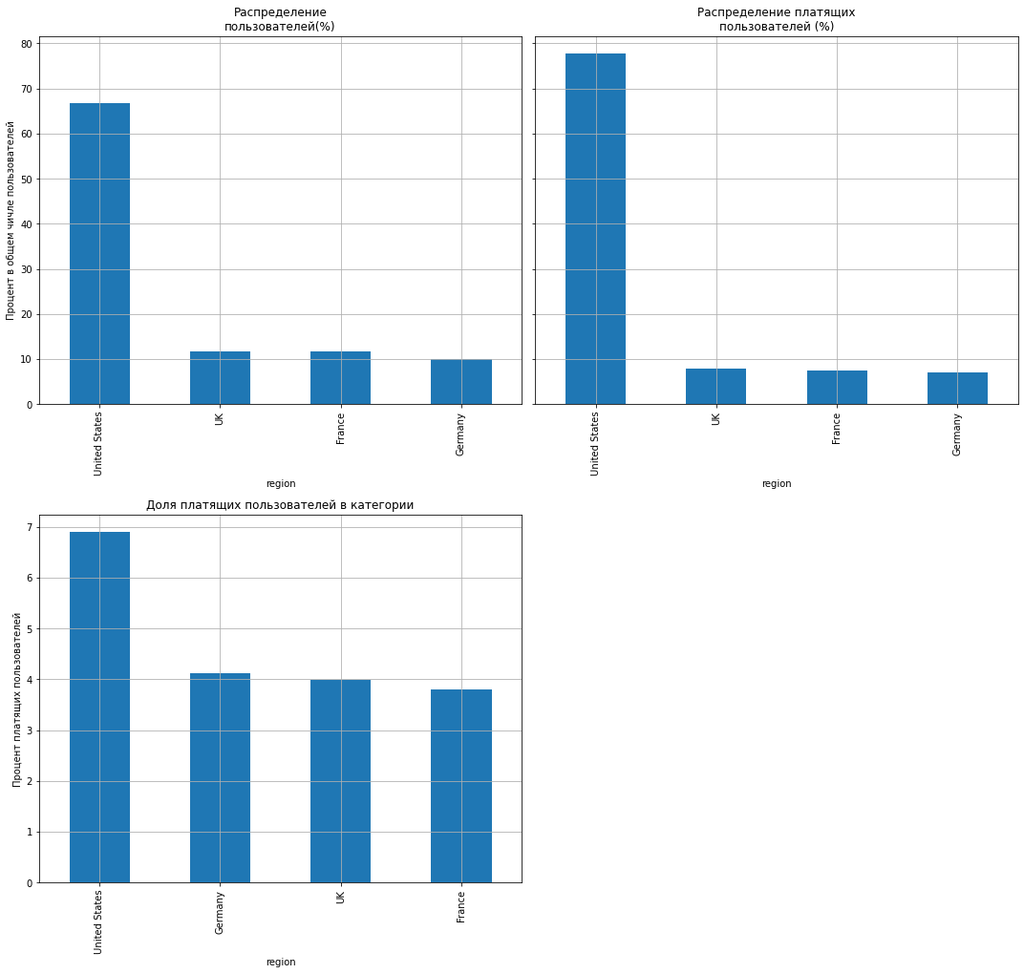

| region | number_of_users | number_of_paying_users | %_paying_users_in_category | %_in_all_users | %_in_all_paying_users |
| --- | --- | --- | --- | --- | --- |
| United States | 100002 | 6902 | 6.90 | 66.66 | 77.72 |
| UK | 17575 | 700 | 3.98 | 11.72 | 7.88 |
| France | 17450 | 663 | 3.80 | 11.63 | 7.47 |
| Germany | 14981 | 616 | 4.11 | 9.99 | 6.94 |

```python
get_profiles_by_category_1(profiles,'region')
```

Посетители приложения приходят из четырех стран : США, Великобритания, Франция и Германия. Большинство пользователей (66,7%) приходят из США, меньше всего из Германии (10%). Доли пользователей из Великобритании и Франции примерно одинаковые (11,7 и 11,6%% соответственно).

Если рассматривать платящих пользователей, то здесь доля посетителй из США составляет 77,7% (% платящих пользователей в этой стране самый высокий 6,9), меньше всего среди платящих пользователей посетителей из Германии (всего 6,9%), посетителей из Великобритании и Франции - 7,9% и 7,5% соответственно.

Наименьшая доля платящих пользователей во Франции (всего 3,8% посетителей из этой страны)

### Исследование пользователей по устройству входа в приложение.

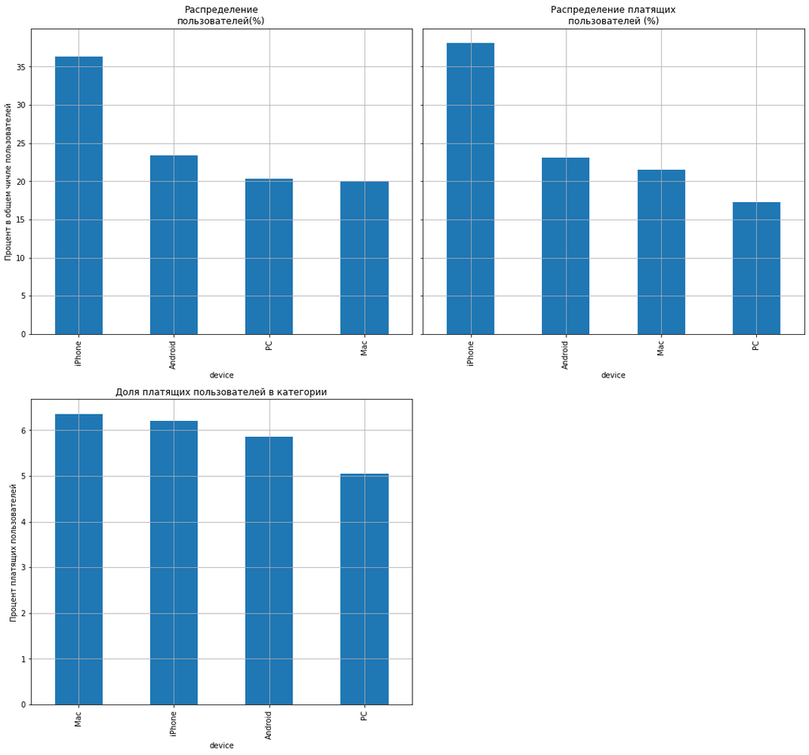

| device | number_of_users | number_of_paying_users | %_paying_users_in_category | %_in_all_users | %_in_all_paying_users |
| --- | --- | --- | --- | --- | --- |
| iPhone | 54479 | 3382 | 6.21 | 36.32 | 38.08 |
| Android | 35032 | 2050 | 5.85 | 23.35 | 23.08 |
| Mac | 30042 | 1912 | 6.36 | 20.03 | 21.53 |
| PC | 30455 | 1537 | 5.05 | 20.30 | 17.31 |

```python
get_profiles_by_category_1(profiles,'device')
```

Клиенты приложения пользуются устройствами iPhone, Mac, Android, PC.

Наибольшую долю среди всех посетителй составляют пользователи iPhone - 36%, меньше всего пользователей Mac и PC (примерно по 20%).

В общем числе платящих посететилей также наибольшую долю составляют пользователи iPhone - 38%, меньше всего среди них пользователей PC - 17%.

Самая большая доля платящих посетителей у пользователей Mac - 6,36%, на втором месте пользователи iPhone. Меньше всего доля платящих клиентов у пользователей PC - 5,05%

### Анализ источников привлечения пользователей.

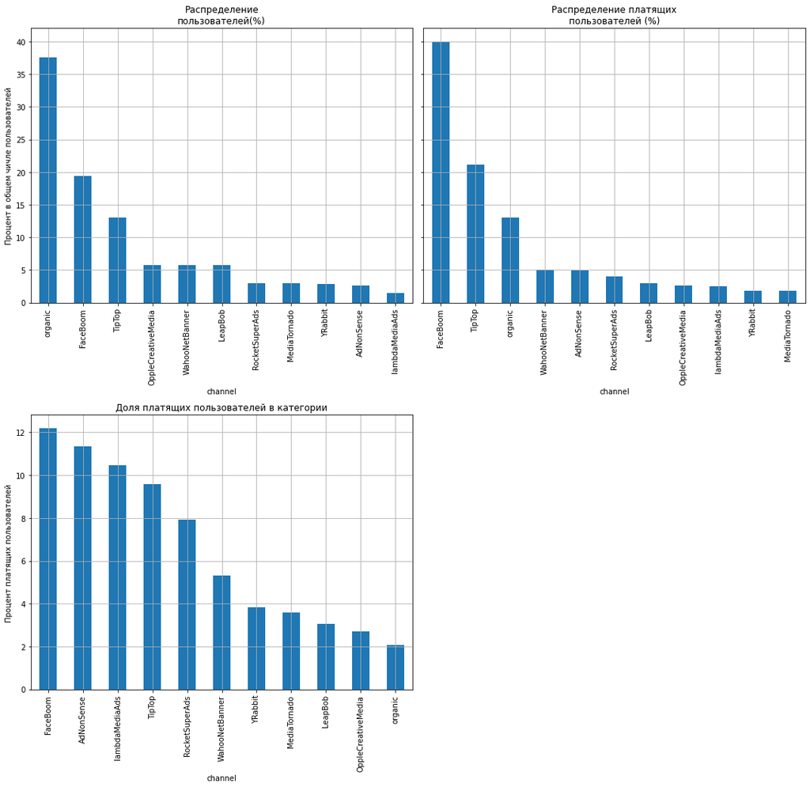

```python
channel = get_profiles_by_category_1(profiles,'channel')
```

```python
channel
```

| channel | number_of_users | number_of_paying_users | %_paying_users_in_category | %_in_all_users | %_in_all_paying_users |
| --- | --- | --- | --- | --- | --- |
| FaceBoom | 29144 | 3557 | 12.20 | 19.43 | 40.05 |
| TipTop | 19561 | 1878 | 9.60 | 13.04 | 21.15 |
| organic | 56439 | 1160 | 2.06 | 37.62 | 13.06 |
| WahooNetBanner | 8553 | 453 | 5.30 | 5.70 | 5.10 |
| AdNonSense | 3880 | 440 | 11.34 | 2.59 | 4.95 |
| RocketSuperAds | 4448 | 352 | 7.91 | 2.97 | 3.96 |
| LeapBob | 8553 | 262 | 3.06 | 5.70 | 2.95 |
| OppleCreativeMedia | 8605 | 233 | 2.71 | 5.74 | 2.62 |
| lambdaMediaAds | 2149 | 225 | 10.47 | 1.43 | 2.53 |
| YRabbit | 4312 | 165 | 3.83 | 2.87 | 1.86 |
| MediaTornado | 4364 | 156 | 3.57 | 2.91 | 1.76 |

Для привлечения пользователей в приложение используется 10 рекламных источников. Почти 38% посетителй приходят в приложение органическим путем. Два основных рекламных источника привлечения - это FaceBoom (19,4 % всех пользователей) и TipTop (13% всех пользователей).

Наибольшее число платящих пользователей приносит FaceBoom - 40% всех платящих пользователей. Доля платящих пользователей у этого канала 12,2%, что более чем в 2 раза выше средней общей доли платящих пользователей (5,9%). 21% платящих пользователей привлек канал TipTop (доля платящих пользователей в этом канале 9,6%).

Можно отметить еще 2 канала с высоким процентом платящих пользователей : AdNonSense (11,3%), lambdaMediaAds (10,5%). Но через эти каналы привлечено всего 2,6% и 1,4% пользователей соответственно.

Наименьший процент платящих пользователей у канала OppleCreativeMedia - 2,7%. Этот показатель очень близок к органическому каналу (2,06%).

## Маркетинг

Определим:

- Сколько денег потратили? Всего / на каждый источник / по времени
- Сколько в среднем стоило привлечение одного покупателя из каждого источника?

### Распределение затрат на маркетинг по источникам привлечения.

Посчитаем общую сумму затрат на маркетинг

```python
(print
 ('Затраты на маркетинг в период с ', profiles['dt'].min(), 'по', profiles['dt'].max(),
 'составили', round(profiles['acquisition_cost'].sum(),2))
)
```

```
Затраты на маркетинг в период с  2019-05-01 по 2019-10-27 составили 105497.3
```

Посмотрим на распределение расходов по источникам привлечения, а также посчитаем средний CAC на одного пользователя по каждому источнику

```python
channel= channel.reset_index()
costs_by_channel =(
    profiles.groupby('channel').agg({'acquisition_cost': 'sum'})
    .rename(columns=({'acquisition_cost':'sum_costs', }))
    .sort_values(by='sum_costs', ascending=False)
    .reset_index()
)
costs_by_channel['%_in_costs'] = (
    round((costs_by_channel['sum_costs'].div(costs_by_channel['sum_costs'].sum(), axis=0)) *100, 2)
)
costs_by_channel = (
    costs_by_channel
    .merge(channel[['channel', 'number_of_users', '%_in_all_users', 'number_of_paying_users', '%_in_all_paying_users']],
           on=['channel'])
)
costs_by_channel['caс_user'] = round(costs_by_channel['sum_costs'] / costs_by_channel['number_of_users'], 2)

costs_by_channel
```

|  | channel | sum_costs | %_in_costs | number_of_users | %_in_all_users | number_of_paying_users | %_in_all_paying_users | caс_user |
| --- | --- | --- | --- | --- | --- | --- | --- | --- |
| 0 | TipTop | 54751.30 | 51.90 | 19561 | 13.04 | 1878 | 21.15 | 2.80 |
| 1 | FaceBoom | 32445.60 | 30.75 | 29144 | 19.43 | 3557 | 40.05 | 1.11 |
| 2 | WahooNetBanner | 5151.00 | 4.88 | 8553 | 5.70 | 453 | 5.10 | 0.60 |
| 3 | AdNonSense | 3911.25 | 3.71 | 3880 | 2.59 | 440 | 4.95 | 1.01 |
| 4 | OppleCreativeMedia | 2151.25 | 2.04 | 8605 | 5.74 | 233 | 2.62 | 0.25 |
| 5 | RocketSuperAds | 1833.00 | 1.74 | 4448 | 2.97 | 352 | 3.96 | 0.41 |
| 6 | LeapBob | 1797.60 | 1.70 | 8553 | 5.70 | 262 | 2.95 | 0.21 |
| 7 | lambdaMediaAds | 1557.60 | 1.48 | 2149 | 1.43 | 225 | 2.53 | 0.72 |
| 8 | MediaTornado | 954.48 | 0.90 | 4364 | 2.91 | 156 | 1.76 | 0.22 |
| 9 | YRabbit | 944.22 | 0.90 | 4312 | 2.87 | 165 | 1.86 | 0.22 |
| 10 | organic | 0.00 | 0.00 | 56439 | 37.62 | 1160 | 13.06 | 0.00 |

Посчитаем средний САС на одного пользователя для всего проекта, используя исходные данные.

```python
# определим первый источник:
first_source = (visits
                .sort_values(by = ['user_id','session_start'])
                .groupby('user_id')
                .agg({'channel' : 'first'})
                .reset_index()
               )

# подсчитаем средний САС:
print(
    'Средний CAC одного пользователя для всей выборки',
    round(costs['costs'].sum() / first_source.query('channel != "organic"').user_id.nunique(), 2)
)
```

```
Средний CAC одного пользователя для всей выборки 1.13
```

Проверим, что средний CAC на одного пользователя, посчитанный из таблицы с профилями такой же.

```python
print(
    'Средний CAC одного пользователя для всей выборки',
    round(profiles.query('channel != "organic"')['acquisition_cost'].mean(), 2)
)
```

```
Средний CAC одного пользователя для всей выборки 1.13
```

Почти 52% затрат приходится на канал TipTop, у этого канала также самый высокий средний показатель CAC -2.8. При этом TipTop находится только на втором месте по привлечению новых пользователей (всего 13% из выборки).

На втором месте по затартам FaceBoom 30,8%. Здесь затраты выглядят более эффективными. Этот канал обеспечивает наибольший прирост пользователей среди всех источников (кроме органического)- 19,4%. Средний САС у FaceBoom 1,11 (более чем в 2 раза ниже чем у TipTop). Через канал FaceBoom пришло 40% всех платящих пользователей.

### Распределение затрат на маркетинг по времени.

Посмотрим на распределение затрат на рекламу по источниками и по времени. Сравним с динамикой привлечения новых пользователей по источникам.

Для удобства дальнейшего анализа отфильтруем профили пользователей, убрав пользователей пришедших в приложение органическим путем

```python
profiles_new = profiles.query('channel != "organic"')
```

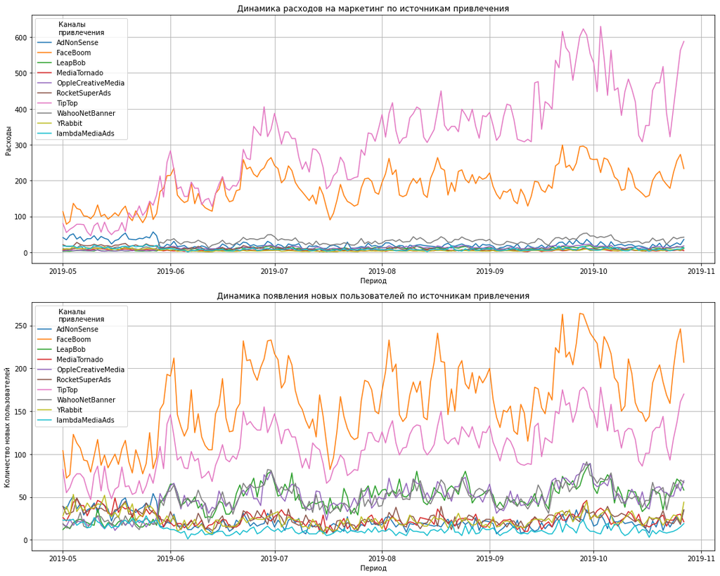

```python
plt.subplots(figsize=(15,12))
ax1 = plt.subplot(2, 1, 1)

(profiles_new .pivot_table(index='dt', columns='channel', values='acquisition_cost', aggfunc='sum')
 .plot(grid=True, ax=ax1)
)
plt.title('Динамика расходов на маркетинг по источникам привлечения')
plt.legend(title='Каналы\nпривлечения')
plt.ylabel('Расходы')
plt.xlabel('Период')

ax2 = plt.subplot(2, 1, 2)
(profiles_new.pivot_table(index='dt', columns='channel', values='user_id', aggfunc='count')
 .plot(grid=True, ax=ax2)
)
plt.title('Динамика появления новых пользователей по источникам привлечения')
plt.legend(title='Каналы\nпривлечения')
plt.ylabel('Количество новых пользователей')
plt.xlabel('Период')

plt.tight_layout()
plt.show()
```

Графики подтверждают сделанные выводы.

Расходы на рекламу начинают расти с июня 2019 г. Большей часть расходы росли по каналу по каналу TipTop - с минимальных значений около 80 в мае до максимальных значений свыше 600 в октябре (более чем в 5 раз). При этом данный канал находится только на 2-м месте по привлечению новых пользователей - их количество выросло примерно с 70 в день в мае до максимальных показателей около 170 в день - в октябре (т.е. только в 2,4 раза).

Наибольший прирост пользователей обеспечивает канал FaceBoom, не смотря на меньший бюджет на рекламу (минимальные затраты в мае около 100 и максимальные в октябре около 300). При этом бюджете канал обеспечил прирост пользователей около 100 в день в мае и максимальный показатель при максимальных затратах на рекламу в октябре - около 260 в день.

**Выводы**

Предварительно можно сказать, что бюджет на рекламу расходовался нерационально.

Для дальнейших выводов необходимо оценить окупаемость рекламных затрат.

## Окупаемость рекламы для привлечения пользователей

С помощью LTV и ROI:

- Проанализируйте общую окупаемость рекламы;
- Проанализируйте окупаемость рекламы с разбивкой по устройствам;
- Проанализируйте окупаемость рекламы с разбивкой по странам;
- Проанализируйте окупаемость рекламы с разбивкой по рекламным каналам.

Опишите проблемы, которые вы обнаружили. Ответьте на вопросы:

- Окупается ли реклама, направленная на привлечение пользователей в целом?
- Какие устройства, страны и рекламные каналы могут оказывать негативное влияние на окупаемость рекламы?
- Чем могут быть вызваны проблемы окупаемости? Изучите конверсию и удержание с разбивкой по устройствам, странам, рекламным каналам.

Опишите возможные причины обнаруженных проблем и сформируйте рекомендации для рекламного отдела. При решении этого шага считайте, что вы смотрите данные 1-го ноября 2019 года и что в вашей организации принято считать, что окупаемость должна наступать не позднее, чем через 2 недели после привлечения пользователей.

**Зададим момент и горизонт анализа**

```python
observation_date = datetime(2019,11, 1).date()  # момент анализа
horizon_days = 14  # горизонт анализа
```

### Общая окупаемость рекламы

Построим общие графики LTV, CAC и ROI, применив имеющиеся функции.

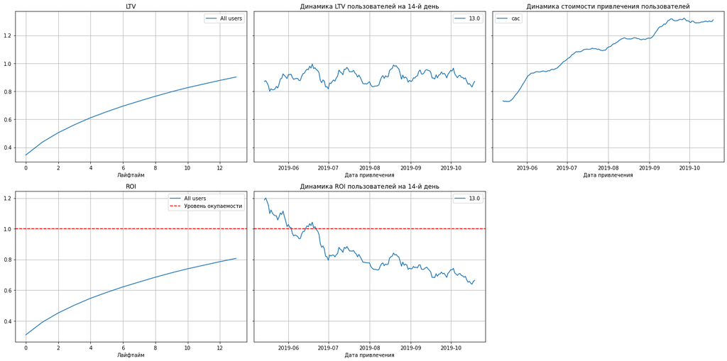

```python
ltv_raw, ltv_grouped, ltv_history, roi_grouped, roi_history = get_ltv(
    profiles_new, orders, observation_date, horizon_days
)


plot_ltv_roi(ltv_grouped, ltv_history, roi_grouped, roi_history, horizon_days)
```

Средний LTV 14-го дня около 0,9 и этот остается примерно на одном уровне весь исследуемый период.

В июне резко возврастает стоимость привлечения новых пользователей, и продолжает расти до сентября. С сентября по ноябрь этот показатель достигает максимальных значений за весь период, но остается примерно на одном уровне.

Затраты на рекламу не окупаются. ROI на 14 день окупает лишь 80% затрат на привлеччние пользователей.Если рассматривать показатель в динамике, видно что в начале периода, до увеличения рекламного бюджета ROI превышал уровень окупаемости на 20%. С июля месяца с резким увеличением стоимости привлечения одного пользователя затраты перестали окупаться, и ROI стабильно снижается до конца периода.

Из-за увеличения стоимости привлечения одного клиента затраты на рекламу перестали окупаться. Что еще раз подтверждает сделанныей выводы о неэффективном расходе средств на рекламу.

### Окупаемость рекламы с разбивкой по устройствам

Посмотрим на эти же показатели с разбивкой по устройствам

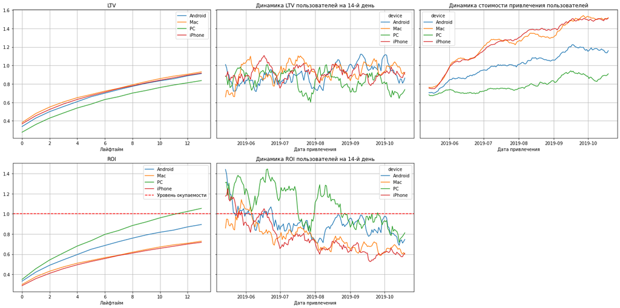

```python
ltv_raw, ltv_grouped, ltv_history, roi_grouped, roi_history = get_ltv(
    profiles_new, orders, observation_date, horizon_days, dimensions=['device']
)


plot_ltv_roi(ltv_grouped, ltv_history, roi_grouped, roi_history, horizon_days)
```

LTV у пользователей Android, MAC и iPhone примерно на одном уровне, у пользователей PC несколько ниже, что ожидаемо.

Динамика LTV по всем устройствам отражает общую картину явных отклонений нет.

На гарфике динамики стоимости привлечения видно, что в целом стоимость привлечения растет у пользователей всех устройств. Но самые дорогие это пользователи MAC и iPhone. Стоимость привлечения этих пользователей изначально была выше и максимально выросла за исследуемый период.

В результате на графике ROI мы видим, что затраты на рекламу окупаются только для пользователей PC. Пользователи Android возвращают на 14 день около 90% затрат на привлечение, MAC и iPhone - только около 70%.

С увеличением стоимости привлечения окупаемость пользователей начинает сокращатся на всех устройствах. Пользователи Android, и iPhone перестали окупаться уже с июня. Выручка пользователей PC перестала превышать уровень окупаемости с сентября. К концу периода не окупается привлечение пользователей всех устройств.

### Окупаемость рекламы с разбивкой по странам

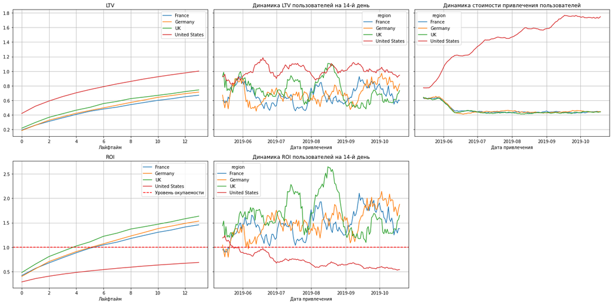

```python
ltv_raw, ltv_grouped, ltv_history, roi_grouped, roi_history = get_ltv(
    profiles_new, orders, observation_date, horizon_days, dimensions=['region']
)

plot_ltv_roi(ltv_grouped, ltv_history, roi_grouped, roi_history, horizon_days)
```

Самый высокий показатель LTV у пользователей из США, самый низкий у пользователей из Франции. Динамика LTV по странамв целом повторяет общую картину.

На графике динамики стоимости привлечения мы видим, что стоимость привлечения пользователей из Германии, Франции и Великобритании сократилась в июне примерно на 33% и сохранялась далее на одном уровне весь исследуемый период. Стоимость привлечения пользователей из США растет на протяжении всего периода, в итоге она выросла более чем в 2 раза, а пользователи из этой страны - это основная часть пользователей приложения.

Соответственно на графиках ROI видно, что пользователи из Великобритании, Германии и Франции стабильно окупаются на протяжении всего периода. Пользователи из США в целом возвращают только 70% затрат на привлечение. На графике динамики ROI видно, что затраты на их привлечение перестали окупаться уже с конца мая. И ROI 14 дня продолжается сокращатся до конца периода.

### Окупаемость рекламы с разбивкой по рекламным каналам

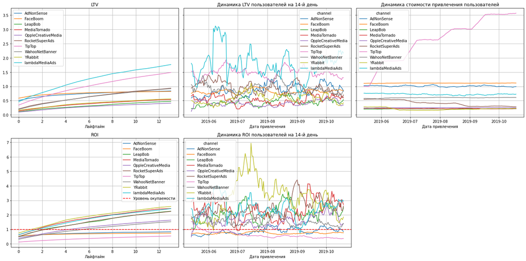

```python
ltv_raw, ltv_grouped, ltv_history, roi_grouped, roi_history = get_ltv(
    profiles_new, orders, observation_date, horizon_days, dimensions=['channel']
)

plot_ltv_roi(ltv_grouped, ltv_history, roi_grouped, roi_history, horizon_days)
```

Самый высокий показатель LTV у пользователей привлеченных lambdaMediaAds, на втором месте TipTop. Динамика LTV по всем каналам в целом стабильна. Единственное, наблюдается спад в сентябре у канала lambdaMediaAds , но к к концу октября показатель возвращается на прежний уровень.

Стоимость привлечения пользователей по всем каналам кроме TipTop и RocketSuperAds остается примерно на одном уровне весь период. Стоимость привлечение пользователей через канал RocketSuperAds снизилась с июля по август почти в 2 раза и остается на этом уровне до конца периода. Стомость привлечения пользователей через канал TipTop росла каждый месяц и увеличилась в 3,5 раза за исследуемый период.

На графике ROI мы видим, что не окупают затраты на рекламу пользователи с 3-х каналов TipTop (самый низкий ROI), FaceBoom и AdNonSence.

На графике динамики ROI можно заметить, что затраты на привлечение по каналу FaceBoom стабильно не окупаются весь период. Пользователи привлеченные через канал TipTop перестали окупаться уже июне, после первого увеличения стоимости привлечения. Далее ROI этих пользователей стабильно снижается. По каналу AdNonSence ROI немного вырос с августа, но в целом окупаемость не превышает затрат на рекламу. Остальные каналы стабильно окупаются в течении всего периода. Максимальные показатели ROI в динамике у канала YRabbit. В июле выручка пользователей, привлеченных этим каналом, более чем в 4 раза превышала затраты на рекламу.

### Общие графики конвесии и удержания

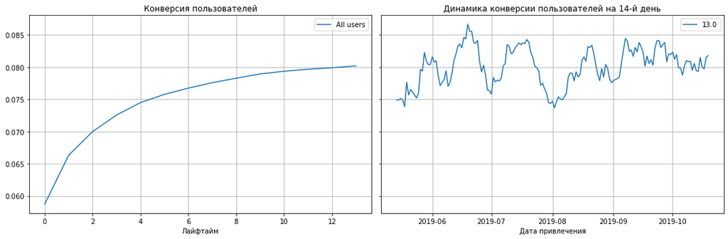

```python
conversion_raw, conversion_grouped, conversion_history = get_conversion(
    profiles_new, orders, observation_date, horizon_days, dimensions=[]
)

plot_conversion(conversion_grouped, conversion_history, horizon_days)
```

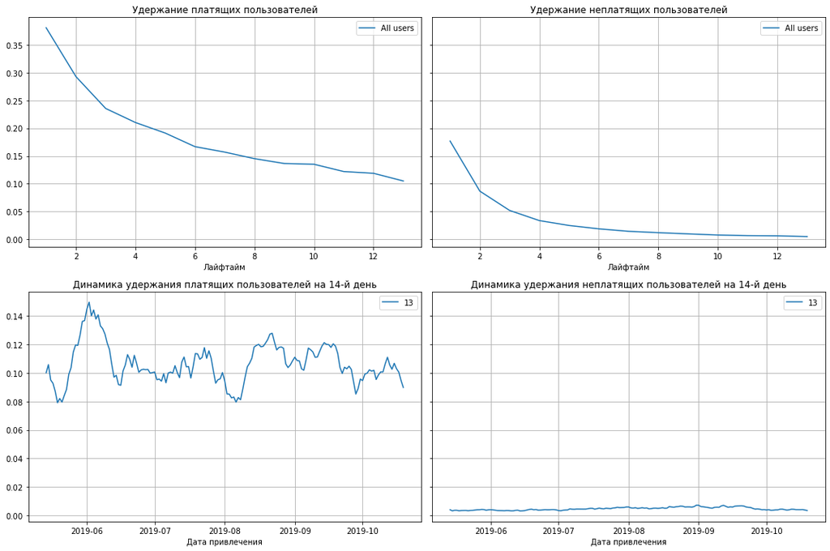

```python
retention_raw, retention_grouped, retention_history = get_retention(
    profiles_new, visits, observation_date, horizon_days, dimensions=[]
)

plot_retention(retention_grouped, retention_history, horizon_days)
```

Судя по общим графикам за период исследования конверсия пользователей на 14 день немного выросла с 7,5 до 8%.

Средний процент удержания платящих пользователей 14 дня около 10. В целом этот показатель не меняется в течении периода. Есть рост до 14 % в конце мая - начале июня, но, с середины июня удержание возвращается к 10%.

### Конверсия и удержание с разбивкой по устройствам.

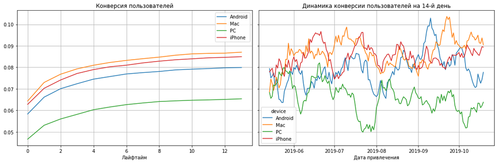

```python
conversion_raw, conversion_grouped, conversion_history = get_conversion(
    profiles_new, orders, observation_date, horizon_days, dimensions=['device']
)

plot_conversion(conversion_grouped, conversion_history, horizon_days)
```

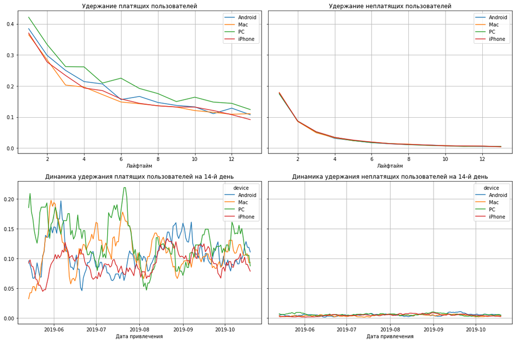

```python
retention_raw, retention_grouped, retention_history = get_retention(
    profiles_new, visits, observation_date, horizon_days, dimensions=['device']
)

plot_retention(retention_grouped, retention_history, horizon_days)
```

У пользователей Mac и iPhone самые высокие показатели конверсии. В динамике на 14 день конверсия пользователей Mac и iPhone также почти весь период находится на высоком уровне и растет в течении исследуемого периода.

Самый высокий процент удержания платящих пользователей у PC (примерно 13% на 14 день), у остальных устройств он примерно одинаков (9-11% на 14 день). Удержание неплатящих пользователей на одном уровне по всем устройствам.

Если смотреть показатель удержания платящих пользователей в динамике на 14 день, то мы видим, что в начале периода удержание по пользователем PC максимально высоко (до 20%), но на протяжении периода этот показатель уменьшается и с августа находится на уровне от 10 до 15%. Также наблюдается существенный рост процета удержания платящих пользователей MAC и Android в период конец мая- начало июня (удержание достигает 20%) и пользователей MAC в июле (около 18%). По остальным устройствам показатели удержания платящих пользователей остаются примерно на одном уровне весь период.

### Конверсия и удержание с разбивкой по странам.

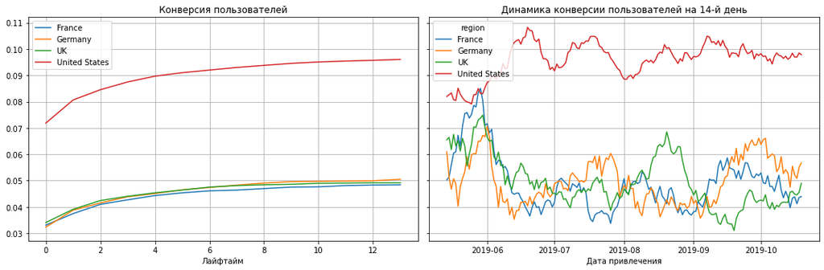

```python
conversion_raw, conversion_grouped, conversion_history = get_conversion(
    profiles_new, orders, observation_date, horizon_days, dimensions=['region']
)

plot_conversion(conversion_grouped, conversion_history, horizon_days)
```

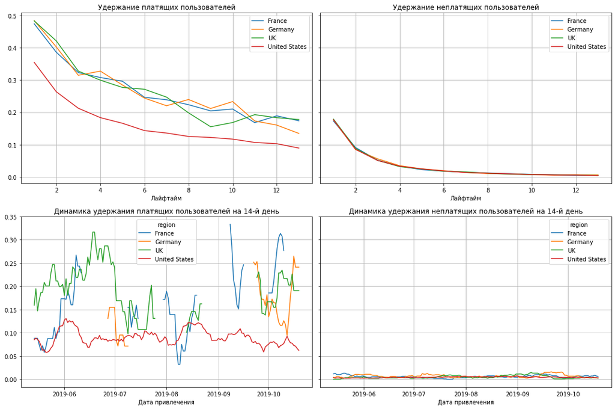

```python
retention_raw, retention_grouped, retention_history = get_retention(
    profiles_new, visits, observation_date, horizon_days, dimensions=['region']
)

plot_retention(retention_grouped, retention_history, horizon_days)
```

У пользователей из США самый высокий показатель конверсии. Если рассматривать динамику на 14 день, конверсия пользователей из США выросла в июне более чем на 25% и остается стабильно высокой на протяжении всего периода. Конверсия 14-го дня пользователей из других также резко выросла в конце мая-начале июня, но затем вернулась примерно к прежним значениям и остается стабильной весь период.

Удержание неплатящих пользователей по всем странам одинаково. Этот показатель в динамике на 14 день также примерно на одном уровне у всех стран.

### Конверсия и удержание пользователей с разбивкой по каналам.

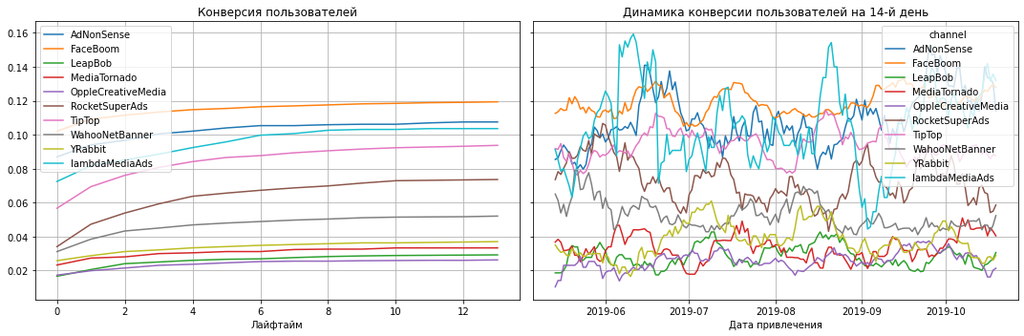

```python
conversion_raw, conversion_grouped, conversion_history = get_conversion(
    profiles_new, orders, observation_date, horizon_days, dimensions=['channel']
)

plot_conversion(conversion_grouped, conversion_history, horizon_days)
```

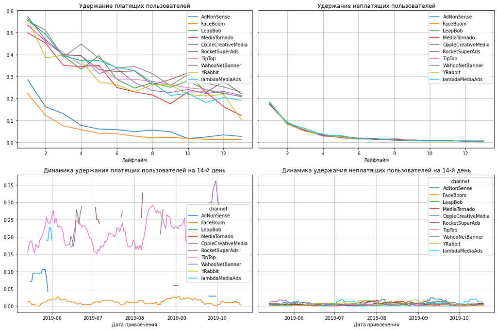

```python
retention_raw, retention_grouped, retention_history = get_retention(
    profiles_new, visits, observation_date, horizon_days, dimensions=['channel']
)

plot_retention(retention_grouped, retention_history, horizon_days)
```

Самая высокая конверсия у пользователей FaceBoom. При этом удержание платящих пользователей этого канала самое низкое. Практическе на том же уровне показатели удержания канала AdNonSense. На графике динамики удержания пользователей дня видно, что процент удержания платящих пользователей FaceBoom весь период близок к 1%.

### Промежуточные выводы.

В целом расходы на рекламу не окупаются. Пользователи возвращают лишь 80% средств потраченных на рекламу.

Если рассматривать затраты на рекламу с разбивкой по устройствам. То дороже всех обходится привлечение пользователей MAC и iPhone. В то же время у пользователей этих устройств самая высокая конверсия. В целом реклама не укупается к концу периода по всем устройствам.

Анализ окупаемости рекламы в разбивке по странам показывает, что затраты на рекламу окупаются во всех странах кроме США. Это связано с ростом затрат на привлечение одного пользователя по этой стране в течении всего периода. А также с самым низким показателем удержания платящих пользователей.

Анализ окупаемости рекламы по каналам выявил следующие проблемы:

Не окупается реклама на 3-х каналах: TipTop, FaceBoom и AdNonSence. По каналу TipTop это связано со значительным увеличением стоимости привлечения одного пользователя, этот показатель растет в течении всего периода. Затраты на рекламу в этом канале перестали окупаться с июня, и ROI сокращается весь период.

У каналов FaceBoom и AdNonSence высокие показатели конверсии, но самые низкие по удержанию платящих пользователей. Возможно рекламма в данных каналах привлекает нецелевую аудиторию приложения.

Как видно рекламы в США в целом характерны проблемы, обнаруженный у рекламных каналов TipTop и FaceBoom, возможно реклама через эти каналы является основным источником привлечения пользователей из этой страны.

### Анализ распределения пользователей из США и Европы в разбивке по каналам привлечения.

Посмотрим на распределение пользователей по рекламным каналам в США и Европе

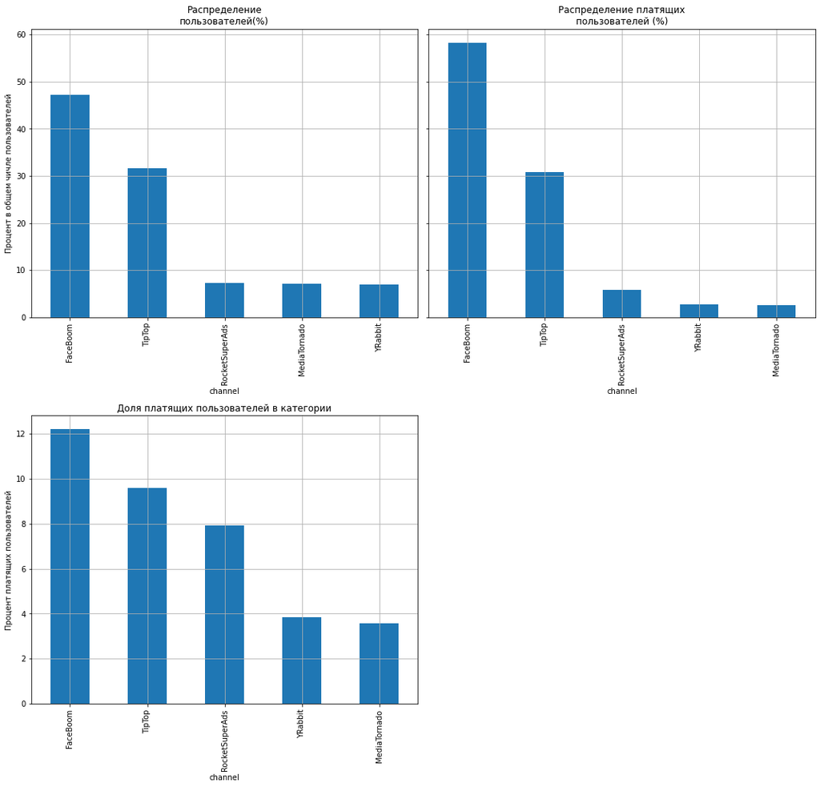

| channel | number_of_users | number_of_paying_users | %_paying_users_in_category | %_in_all_users | %_in_all_paying_users |
| --- | --- | --- | --- | --- | --- |
| FaceBoom | 29144 | 3557 | 12.20 | 47.14 | 58.24 |
| TipTop | 19561 | 1878 | 9.60 | 31.64 | 30.75 |
| RocketSuperAds | 4448 | 352 | 7.91 | 7.19 | 5.76 |
| YRabbit | 4312 | 165 | 3.83 | 6.97 | 2.70 |
| MediaTornado | 4364 | 156 | 3.57 | 7.06 | 2.55 |

```python
get_profiles_by_category_1(profiles_new.query('region == "United States"'),'channel')
```

В США используется 5 каналов для привлечения пользователей. Если сравнить количество пользователей привлеченных этими каналами в США с общей таблицей с каналами привлечения по всем странам, то понятно, что через эти каналы приходят в приложение только пользователи из США.

Более 60% пользователей из США, привлеченных в приложение рекламой, приходят через каналы FaceBoom и TipTop. Отсюда и низкие показатели окупаемости рекламы и удержания платящих пользователей в целом по стране.

Посмотрим на распределение пользователей по рекламным каналам привлечения в странах Европы.

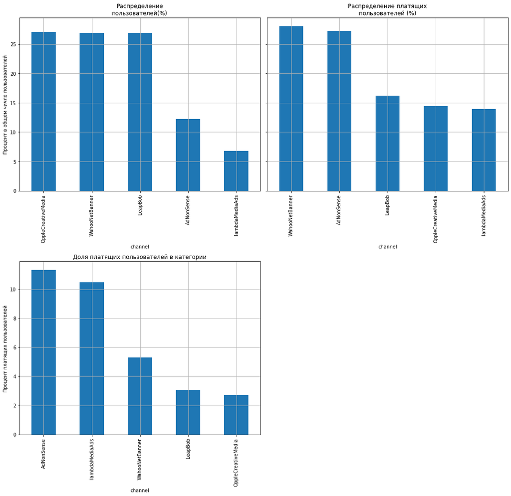

| channel | number_of_users | number_of_paying_users | %_paying_users_in_category | %_in_all_users | %_in_all_paying_users |
| --- | --- | --- | --- | --- | --- |
| WahooNetBanner | 8553 | 453 | 5.30 | 26.95 | 28.08 |
| AdNonSense | 3880 | 440 | 11.34 | 12.22 | 27.28 |
| LeapBob | 8553 | 262 | 3.06 | 26.95 | 16.24 |
| OppleCreativeMedia | 8605 | 233 | 2.71 | 27.11 | 14.45 |
| lambdaMediaAds | 2149 | 225 | 10.47 | 6.77 | 13.95 |

```python
get_profiles_by_category_1(profiles_new.query('region != "United States"'),'channel')
```

В странах Европы пользователи более равномерно распределены по каналам привлечения. Канал AdNonSense, затраты на рекламу в которм не окупаются привлекает лишь 12% пользователей, приходящих через рекламные каналы.

## Выводы.

В ходе исследования мы выяснили, что в приложение приходят пользователи из стран: США, Великобритания, Германия и Франция. Основная часть пользователей (67%) это поользователи из США.

Устройства пользователей это iPhone, MAC, Android и PC. Больше всего пользователей, использующих iPhone (36%). Доля остальных устройств от 20 до 23%.

Всего для привлечения пользователй используется 10 рекламных каналов - 5 для пользователей США и 5 для пользователей из стран Европы. Почти 38% пользователей приходят в приложение органическим путем. Наибольшую долю новых пользователей привлекает канал FaceBoom (более 19%), на втором месте канал TipTop (13%). Самая высокая стоимость привлечения одного клиента у канала TipTop (2.8), на втором месте FaceBoom (1.11), третий самый дорогой канал AdNonSense (стоимость привлечения одного пользователя 1.01).

Средняя стоимость привлечения одного клиента 1.13

В среднем каждый клиент приносит на 14 день выручку 0.9 (80% от средних рекламных расходов на привлечение)

Затраты на рекламу в целом не окупаются.

Анализ окупаемости с разбивкой по каналам показал, что рекламные затраты не окупаются у трех каналов : FaceBoom, TipTop и AdNonSense (самые дорогие каналы по стоимости привлечения одного клиента). У этих каналов самые высокие показатели конверсии, но причины их неокупаемости в следуещем:

- У канала TipTop высокая средняя стоимость привлечения одного пользователя (2.8). Канал повышает стоимость рекламы в течении всего периода, затраты перестают окупаться уже в июне. В результате на рекламу в этом канале ушло 52% всего бюджета. А средний ROI 14 дня всего лишь 0.54.
- Причина неокупаемости каналов FaceBoom и AdNonSense в низком удержании платящих пользователей. Средний показатель удержания платящих пользователей 14 дня для FaceBoom - 1.2%, для AdNonSense - 2%. Соответственно средний ROI у FaceBoom - 0.74, у AdNonSense - 0.83. Возможно низкий уровень удержания платящих пользователей, связан с тем, что реклама через эти каналы привлекает нецелевую аудиторию приложения.

**Рекомендации для отдела маркетенга:**

- Отказатся от привлечения пользователей через каналы FaceBoom, TipTop и AdNonSense.
- Следить за динамикой показателей стоимости привлечения, удержания платящих пользователей и окупаемости рекламных затрат.
- При распределении бюджета на рекламу, сейчас стоит обратить внимание на каналы с высокими показателями окупаемость. Для США это RocketSuperAds - средний ROI 14 дня - 2.23, процент удержания платящих пользователей 22. Для Европы - lambdaMediaAds (средний ROI 14 дня - 2.47, процент удержания платящих пользователей - 19 и самый высокий по каналам средний LTV 14 дня - 1.77).